# HCAMP RTL

## Data Description

To create a valid data frame consisting of ImPACT scores, PCSS scores, and RTL/RTP information from the SIMS data set, the following steps were taken:

1. Injuries labeled as “Head Concussion” were identified and isolated from the SIMS data set.
2. Three variables were created to represent the duration of time from onset to RTP step 2 (*Return to School Full Time*), RTP step 2 to RTP step 7 (*Full Return to Activity*), and from onset to RTP step 7. These three variables are referred to as:
- `onset_rtl_total_days`
- `rtl_rtp_total_days`
- `onset_rtp_total_days`
3. Missing data on the dates of injury onset as well as the achievement of RTP steps 2 and 7 was removed.
4. Individuals with a duration of time less than 0 days for the aforementioned three variables were removed.
5. This data set then consisted of 827 injuries
6. When combined with the ImPACT Post-Injury 1 data set, the removal of missing data left 238 injuries
7. A new variable was created (`days_between_injury_test_date`) to quantify the duration of time between the onset date (SIMS data set) and the test date (ImPACT data set). Injuries were kept in the data set if the duration of time from onset to test date was between 0-30 days. With injuries outside this range removed, the new data set to be used for analysis consists of 208 injuries.

## Data Exploration - SIMS Demographic Information

### Gender

| Gender | Total |
| --- | --- |
| Female | 78 |
| Male | 130 |

### Age

| Age | Total |
| --- | --- |
| 13 | 1 |
| 14 | 49 |
| 15 | 63 |
| 16 | 43 |
| 17 | 40 |
| 18 | 12 |

### League

| League | Total |
| --- | --- |
| BIIF | 50 |
| KIF | 62 |
| MIL | 96 |

### School

| League | School | Total |
| --- | --- | --- |
| MIL | Maui High School | 38 |
| KIF | Waimea High School | 37 |
| BIIF | Konawaena High School | 26 |
| MIL | Baldwin High School | 26 |
| KIF | Kapaa High School | 23 |
| MIL | Lahainaluna High School | 17 |
| MIL | King Kekaulike High School | 12 |
| BIIF | Honokaa High School | 8 |
| BIIF | Keaau High School | 7 |
| BIIF | Waiakea High School | 6 |

[output cut: 4 more lines]

### Sport

| Sport | Total |
| --- | --- |
| Football | 86 |
| Women's Soccer | 21 |
| Cheerleading | 12 |
| Women's Volleyball | 11 |
| Softball | 10 |
| Baseball | 9 |
| Men's Soccer | 9 |
| Men's Basketball | 7 |
| Not team related | 7 |
| Men's Wreslting | 6 |

[output cut: 11 more lines]

### Sport Level

| Level | Total |
| --- | --- |
| Junior Varsity | 67 |
| Varsity | 104 |
| NA | 37 |

## Data Exploration - SIMS RTP Information

### Duration of Time from Onset to RTP Completion

#### Quick Summary

| Mean | SD | Min | Max | Total |
| --- | --- | --- | --- | --- |
| 25.45 | 31.75 | 5 | 291 | 208 |

#### Gender Summary

| Gender | Mean | SD | Min | Max | Total |
| --- | --- | --- | --- | --- | --- |
| Female | 29.0128205128205 | 43.9310243271756 | 5 | 291 | 78 |
| Male | 23.3153846153846 | 21.2992828846727 | 6 | 192 | 130 |

#### Age Summary

| Age | Mean | SD | Min | Max | Total |
| --- | --- | --- | --- | --- | --- |
| 13 | 18 | NA | 18 | 18 | 1 |
| 14 | 29.5510204081633 | 52.7849651986284 | 8 | 291 | 49 |
| 15 | 29.7301587301587 | 29.014015717217 | 6 | 192 | 63 |
| 16 | 19.1162790697674 | 8.58905533451225 | 5 | 50 | 43 |
| 17 | 21.4 | 17.567160504906 | 7 | 98 | 40 |
| 18 | 23.0833333333333 | 16.9515798852514 | 7 | 56 | 12 |

#### League Summary

| League | Mean | SD | Min | Max | Total |
| --- | --- | --- | --- | --- | --- |
| BIIF | 20.7 | 25.5304939718953 | 8 | 192 | 50 |
| KIF | 27.6451612903226 | 39.0212622890303 | 5 | 291 | 62 |
| MIL | 26.5104166666667 | 29.4428955926076 | 6 | 269 | 96 |

#### Visualizations

##### Age and Gender

###### Age 14

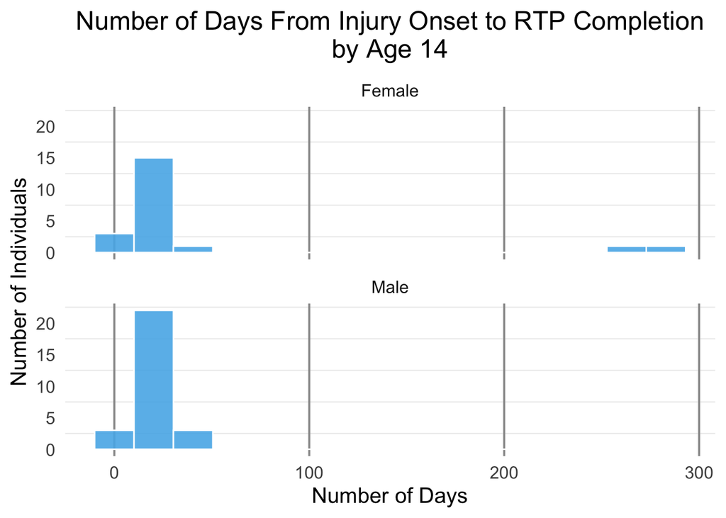

###### Age 15

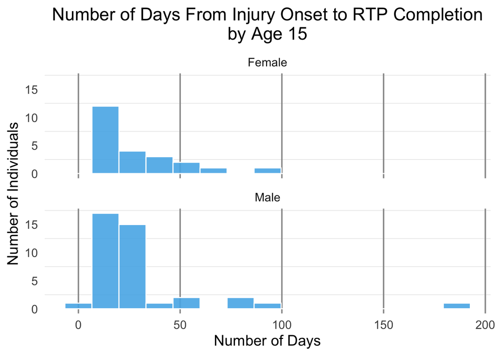

###### Age 16

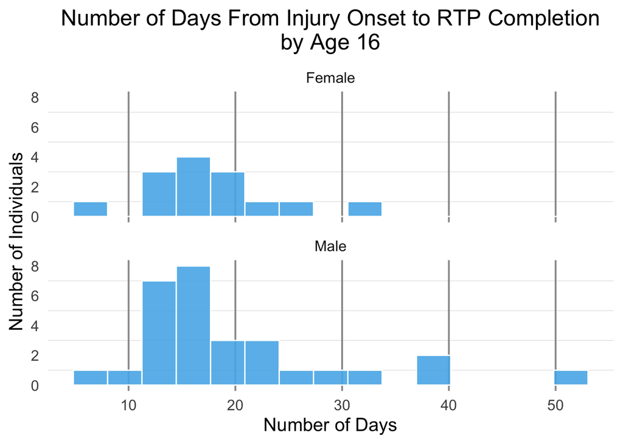

###### Age 17

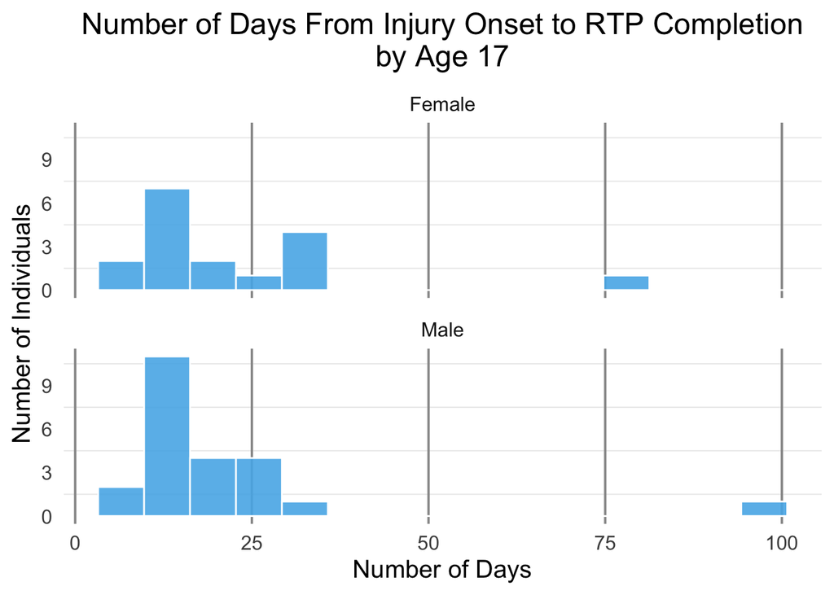

###### Age 18

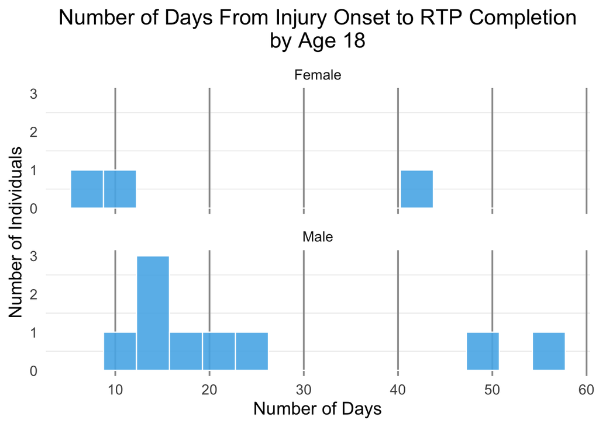

##### League and Gender

###### BIIF

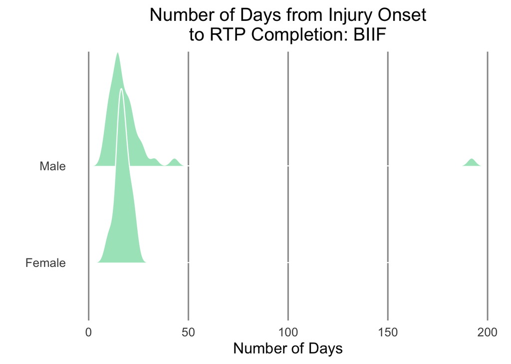

###### KIF

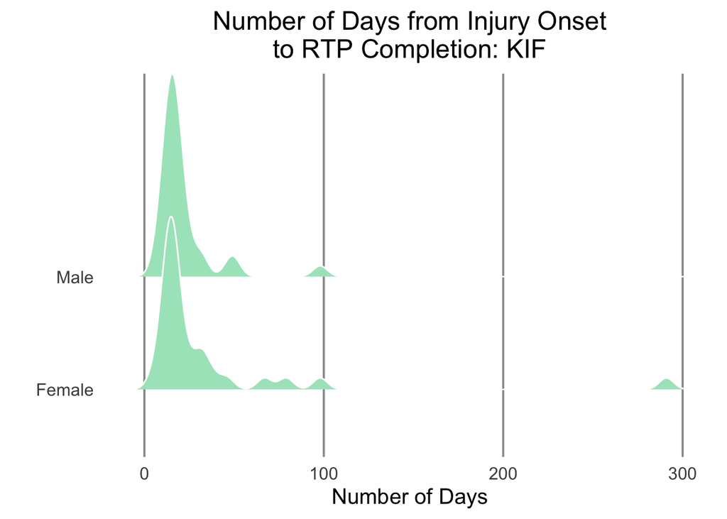

###### MIL

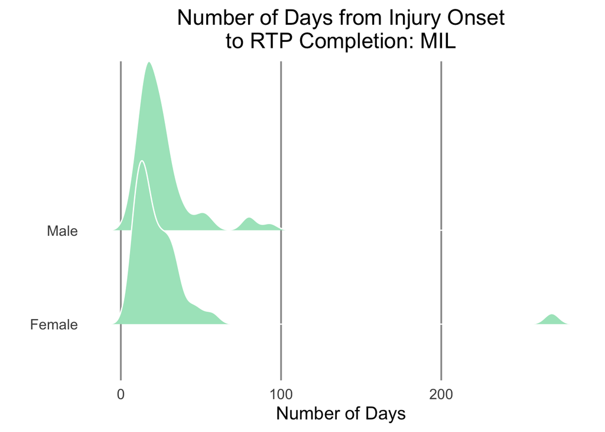

### Duration of Time from Onset to RTL Completion

#### Quick Summary

| Mean | SD | Min | Max | Total |
| --- | --- | --- | --- | --- |
| 4.26 | 4.79 | 0 | 27 | 208 |

#### Gender Summary

| Gender | Mean | SD | Min | Max | Total |
| --- | --- | --- | --- | --- | --- |
| Female | 4.97435897435897 | 5.59214281577834 | 0 | 27 | 78 |
| Male | 3.83846153846154 | 4.19450331742682 | 0 | 25 | 130 |

#### Age Summary

| Age | Mean | SD | Min | Max | Total |
| --- | --- | --- | --- | --- | --- |
| 13 | 3 | NA | 3 | 3 | 1 |
| 14 | 4.06122448979592 | 4.82358858141126 | 0 | 22 | 49 |
| 15 | 5.06349206349206 | 5.95919732599092 | 1 | 27 | 63 |
| 16 | 3.18604651162791 | 3.47957177136366 | 0 | 20 | 43 |
| 17 | 4.525 | 4.32635038945156 | 1 | 18 | 40 |
| 18 | 4 | 2.79610118167813 | 1 | 10 | 12 |

#### League Summary

| League | Mean | SD | Min | Max | Total |
| --- | --- | --- | --- | --- | --- |
| BIIF | 3.3 | 3.20235882449427 | 1 | 18 | 50 |
| KIF | 4.70967741935484 | 4.85658956360508 | 0 | 27 | 62 |
| MIL | 4.47916666666667 | 5.36652228202854 | 0 | 25 | 96 |

#### Visualizations

##### Age and Gender

###### Age 14

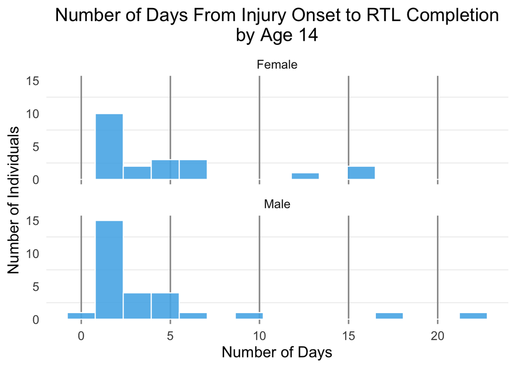

###### Age 15

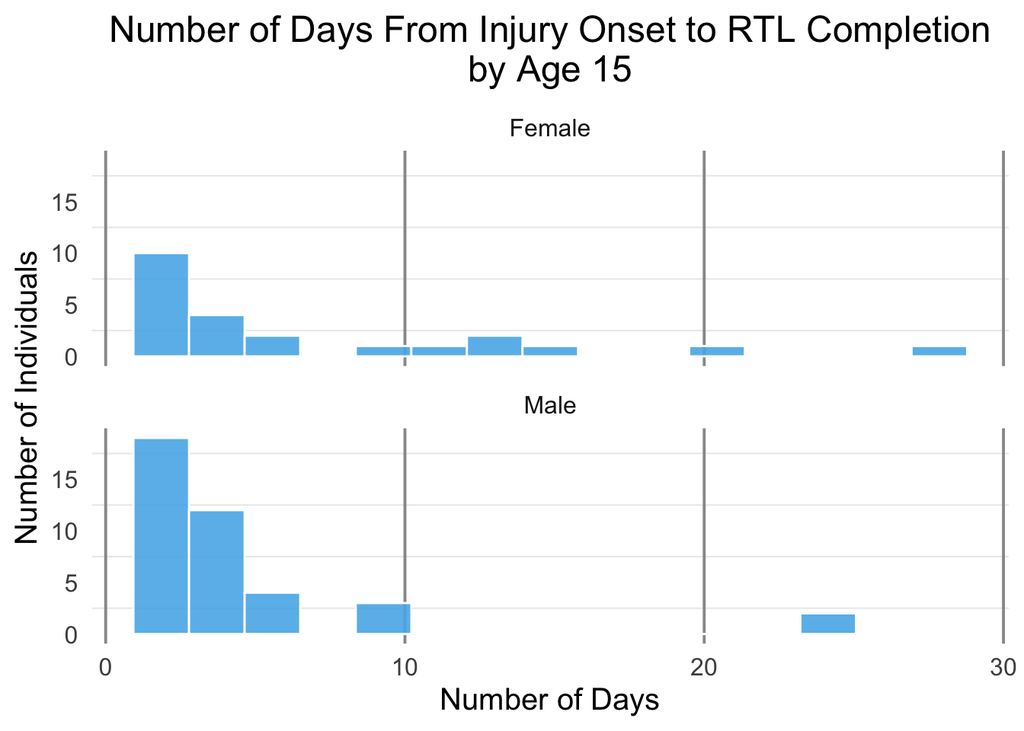

###### Age 16

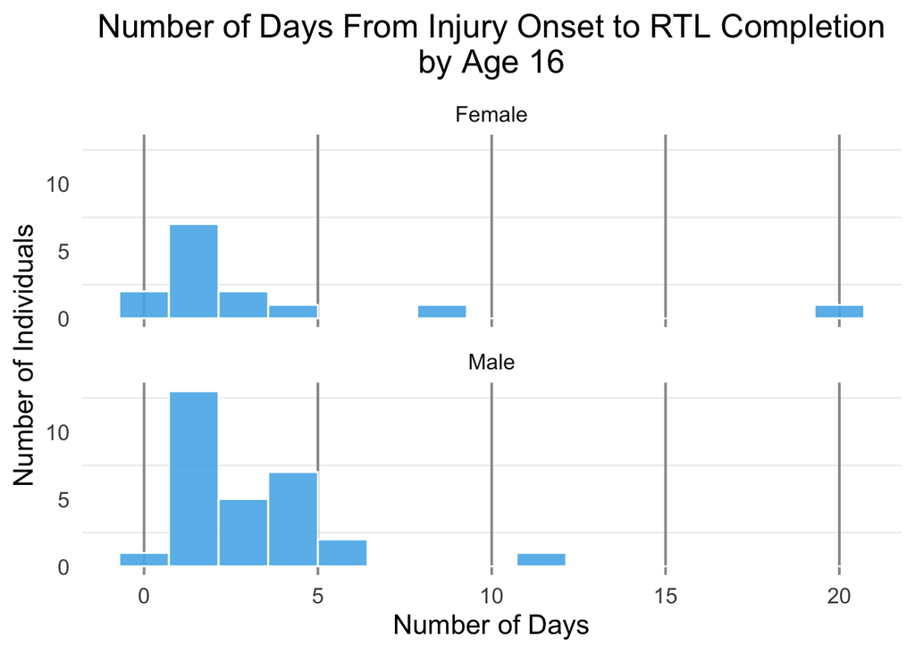

###### Age 17

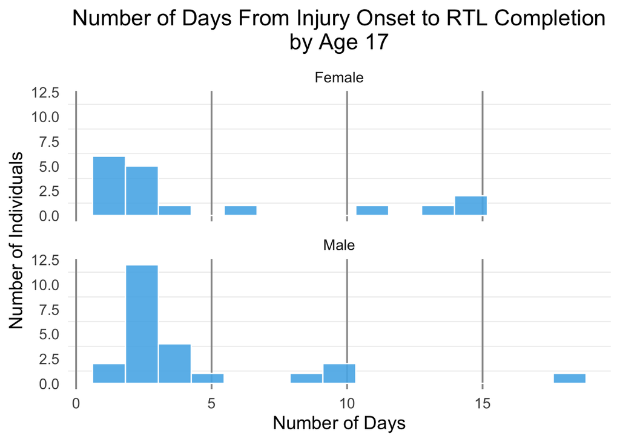

###### Age 18

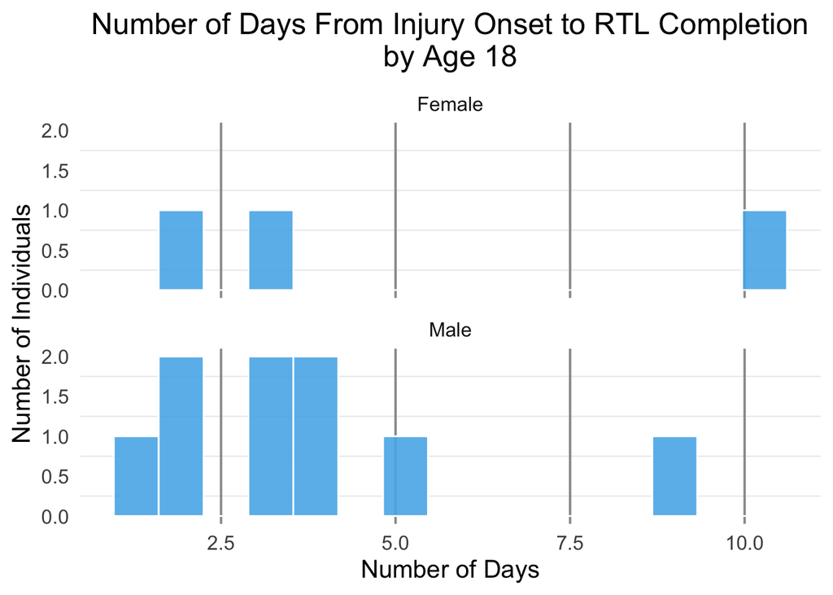

##### League and Gender

###### BIIF

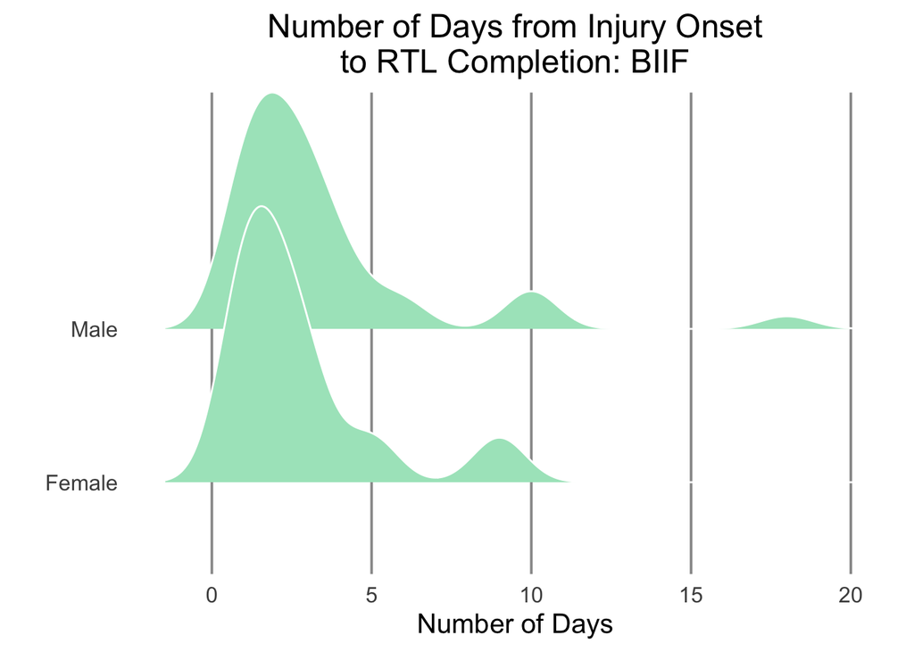

###### KIF

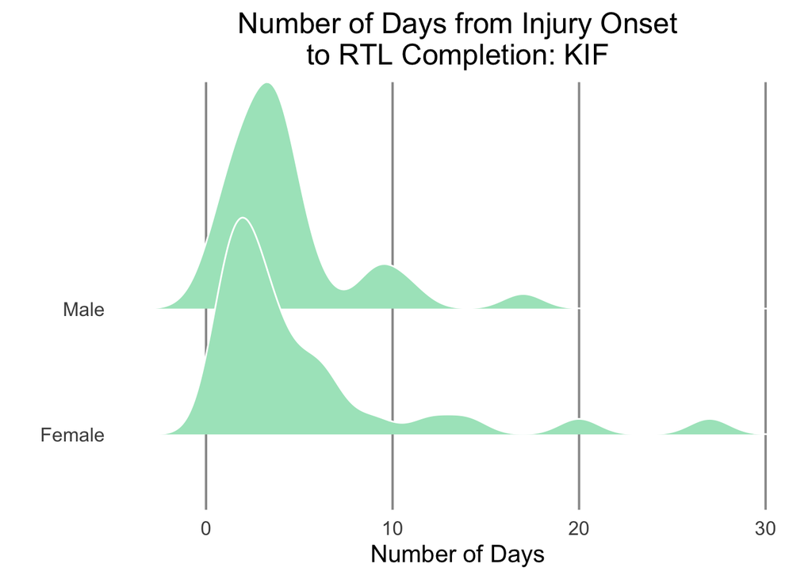

###### MIL

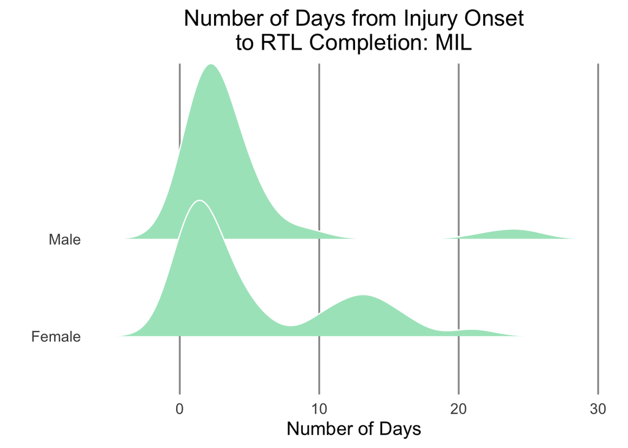

### Duration of Time from RTL Completion to RTP Completion

#### Quick Summary

| Mean | SD | Min | Max | Total |
| --- | --- | --- | --- | --- |
| 21.19 | 31.21 | 0 | 284 | 208 |

#### Gender Summary

| Gender | Mean | SD | Min | Max | Total |
| --- | --- | --- | --- | --- | --- |
| Female | 24.0384615384615 | 43.3626933760252 | 0 | 284 | 78 |
| Male | 19.4769230769231 | 20.8104086153594 | 0 | 190 | 130 |

#### Age Summary

| Age | Mean | SD | Min | Max | Total |
| --- | --- | --- | --- | --- | --- |
| 13 | 15 | NA | 15 | 15 | 1 |
| 14 | 25.4897959183673 | 52.7423463835353 | 0 | 284 | 49 |
| 15 | 24.6666666666667 | 27.2396769437525 | 0 | 190 | 63 |
| 16 | 15.9302325581395 | 8.42726682472468 | 4 | 48 | 43 |
| 17 | 16.875 | 18.0585763416494 | 0 | 96 | 40 |
| 18 | 19.0833333333333 | 15.7910120196921 | 4 | 51 | 12 |

#### League Summary

| League | Mean | SD | Min | Max | Total |
| --- | --- | --- | --- | --- | --- |
| BIIF | 17.4 | 25.9442101598088 | 0 | 190 | 50 |
| KIF | 22.9354838709677 | 38.1772702816149 | 0 | 284 | 62 |
| MIL | 22.03125 | 28.8007504014081 | 0 | 268 | 96 |

#### Visualizations

##### Age and Gender

###### Age 14

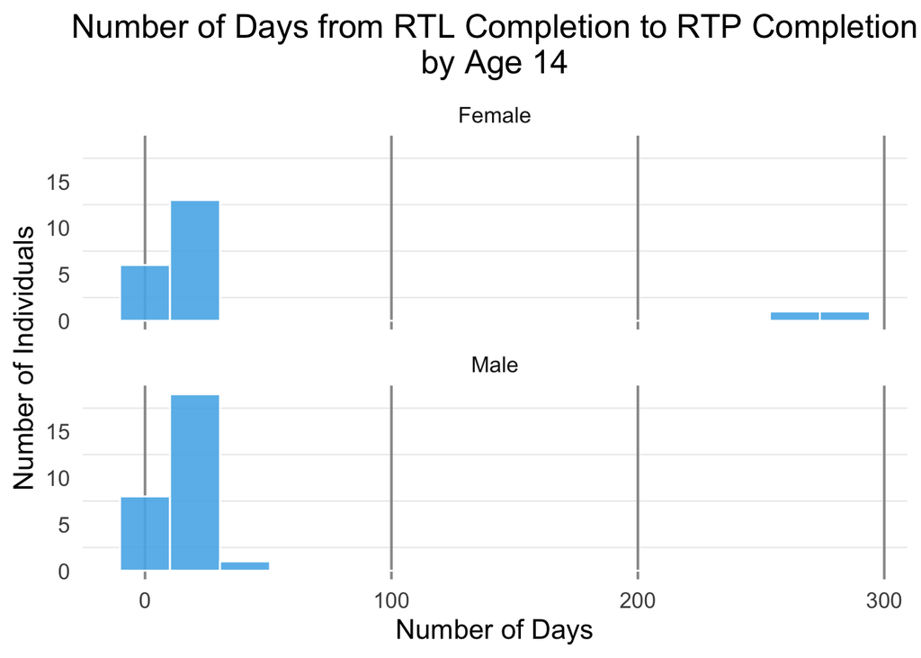

###### Age 15

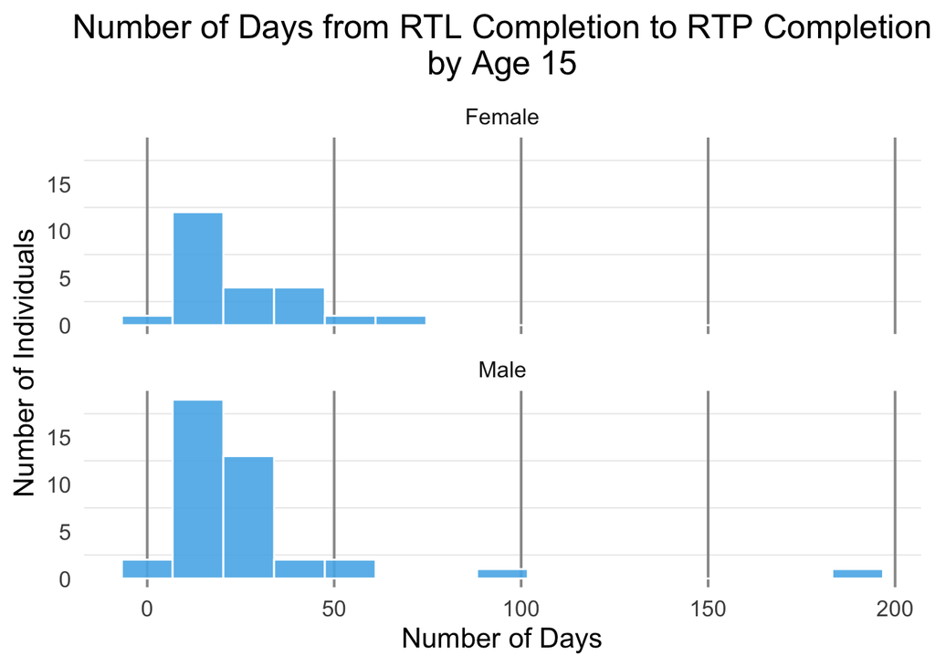

###### Age 16

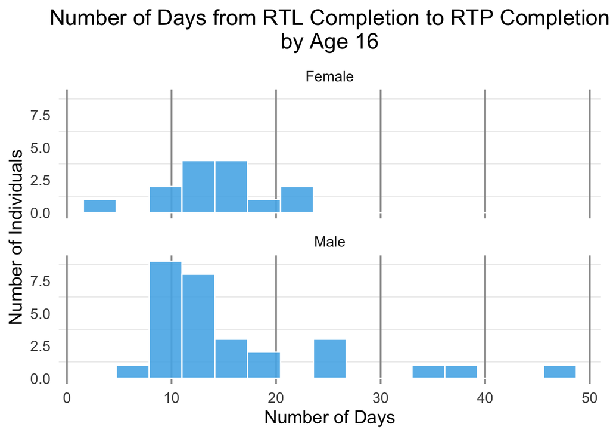

###### Age 17

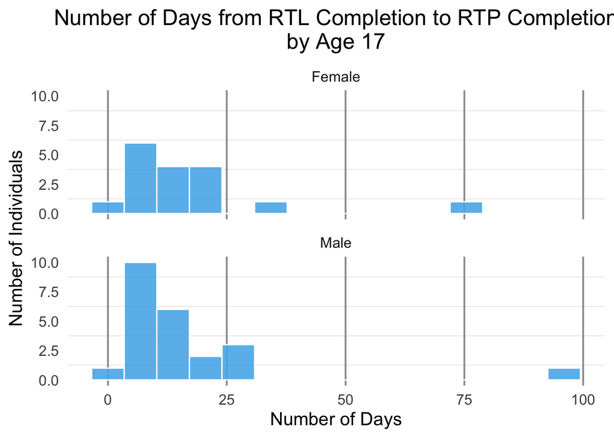

###### Age 18

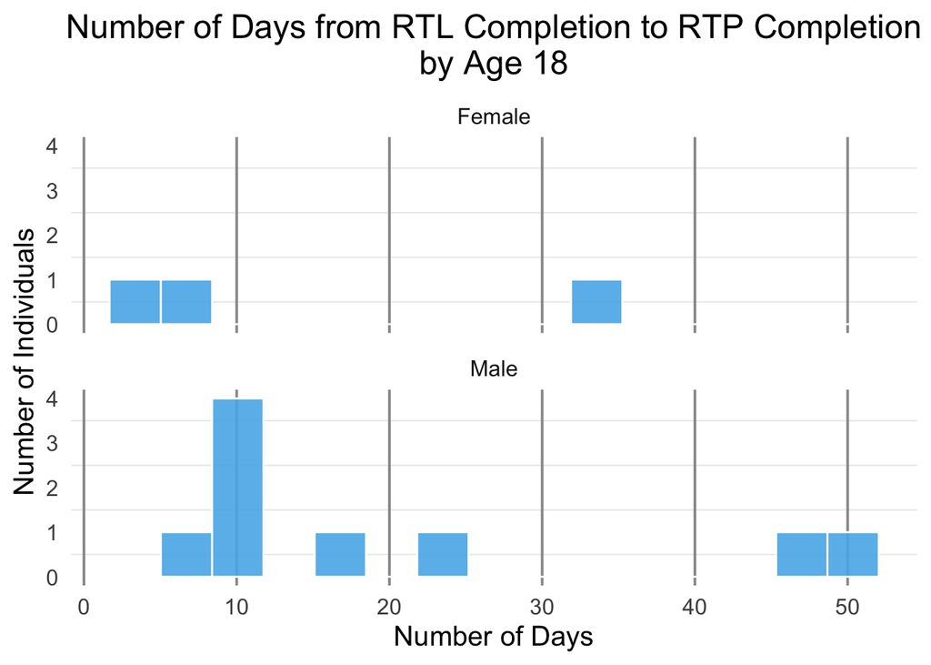

##### League and Gender

###### BIIF

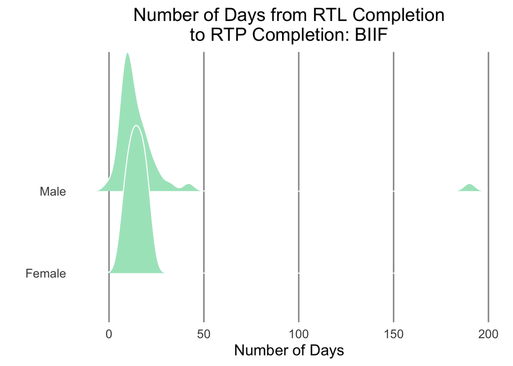

###### KIF

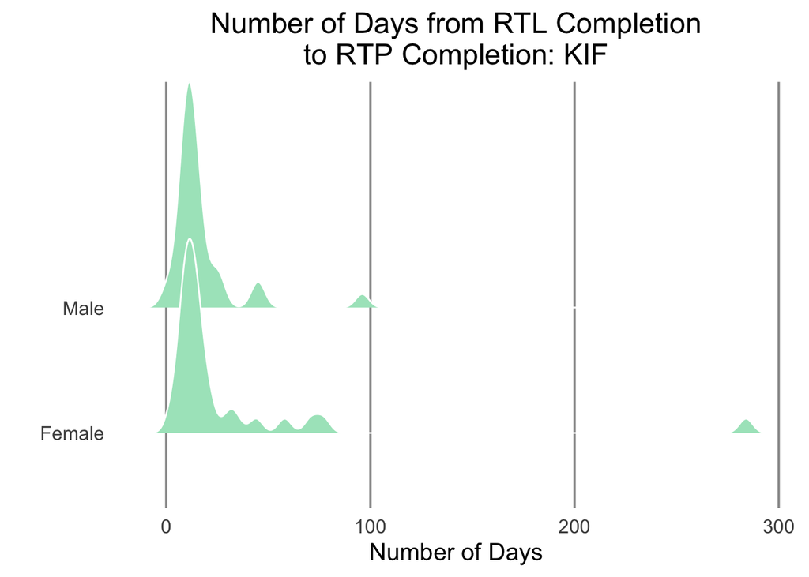

###### MIL

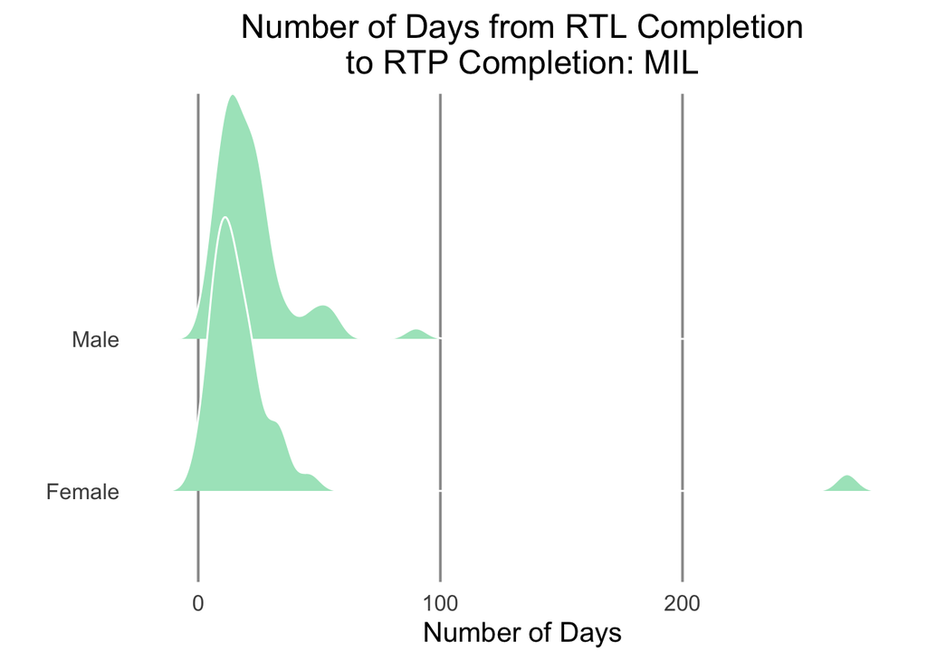

## Data Exploration - ImPACT PCSS Scores

### Time between Injury Onset and Test Date

To calculate the duration of time from injury onset (`onset`) and ImPACT test date where PCSS scores were collected (`test_date`), a variable was created (`days_between_injury_test_date`) to represent this duration of time. Injuries where testing occurred more than 30 days after the injury were removed from the data set.

| Mean | SD | Min | Max | Total |
| --- | --- | --- | --- | --- |
| 5.58 | 5.17 | 0 | 28 | 208 |

### PCSS Symptom Category Description

Using Lumba-Brown et al. (2019) and Harmon et al. (2019) as references, the 22 PCSS symptoms were organized into the following six symptom clusters:

1. Headache-Migraine Symptoms Cluster (Total Possible Score: 18)
- Headache (PCSS symptom 1)
- Light Sensitivity (PCSS symptom 11)
- Noise Sensitivity (PCSS symptom 12)
2. Cognitive Symptoms Cluster (Total Possible Score: 24)
- Difficulty Concentrating (PCSS symptom 20)
- Difficulty Remembering (PCSS symptom 21)
- Feeling “Slow” (PCSS symptom 18)
- Feeling “Foggy” (PCSS symptom 19)
3. Anxiety-Mood Symptoms Cluster (Total Possible Score: 30)
- Irritability (PCSS symptom 13)
- Sadness (PCSS symptom 14)
- Nervousness (PCSS symptom 15)
- More Emotional (PCSS symptom 16)
- Numbness (PCSS symptom 17)
4. Ocular-Motor Symptoms Cluster (Total Possible Score: 6)
- Visual Problems (PCSS symptom 22)
5. Vestibular Symptoms Cluster (Total Possible Score: 24)
- Dizziness (PCSS symptom 5)
- Balance Problems (PCSS symptom 4)
- Nausea (PCSS symptom 2)
- Vomiting (PCSS symptom 3)
6. Sleep Symptoms Cluster (Total Possible Score: 30)
- Fatigue (PCSS symptom 6)
- Trouble Falling Asleep (PCSS symptom 7)
- Excessive Sleep (PCSS symptom 8)
- Loss of Sleep (PCSS symptom 9)
- Drowsiness (PCSS symptom 10)

PCSS Total Possible Score: 132